# 愛知県 (議員定数：15 → 16)

アルゴリズムによる衆議院小選挙区の区割り改訂案

**愛知県**

人口： 7,164,729 人（2020年）

|  | 現行 | アルゴリズムの提案 |
| --- | --- | --- |
| **1票の格差** |  |  |
| 県内較差 | 1.575 | 1.234 |
| 改善率 | - | 59.3% |
| **選挙区の状況** |  |  |
| 選挙区数 | 15 | 16 |
| 市区町村の分割 | 3<sup>a</sup> | 2<sup>b</sup> |
| 郡の分割 | 0 | 0 |
| 広域連携地域の分割 | 1<sup>c</sup> | 0 |

<sup>*a*</sup> 豊田市、一宮市、瀬戸市 <sup>*b*</sup> 名古屋市熱田区、港区 <sup>*c*</sup> 衣浦定住自立圏

# 現行の区割り

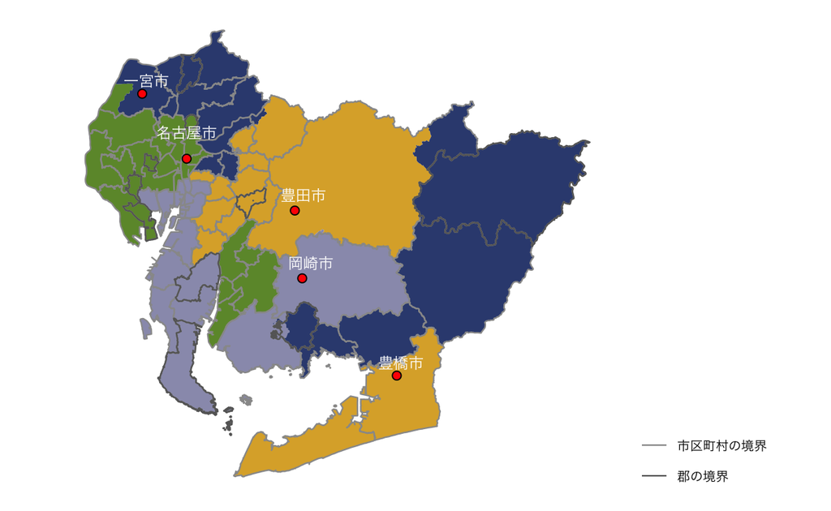

# アルゴリズムの提案

アルゴリズムが提案した25,000案のうち、有効な案の中で、一票の格差が最小のもの

一票の格差 : 1.234

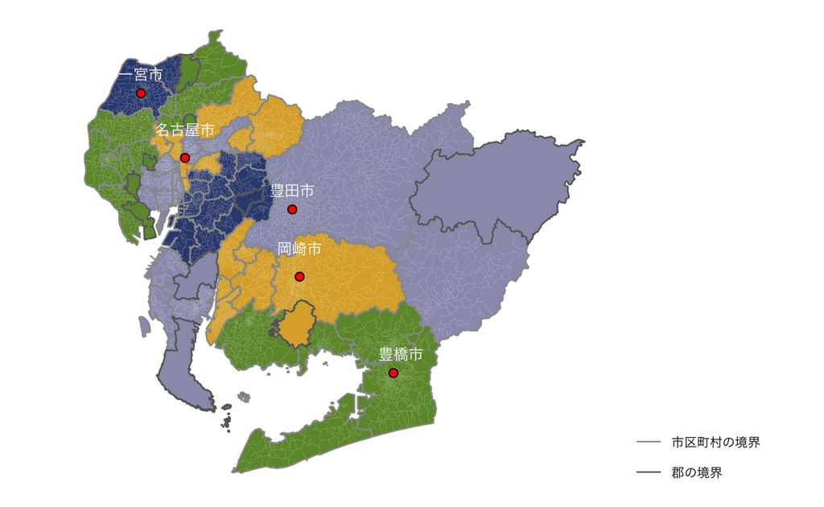

# 共起分析

- アルゴリズム設定
  - 市区町村の分割無し
  - 飛び地を含む案を棄却
  - 一票の格差が下位10％の案を抽出
- 読み取り方  
  地図上の市区町村の色が
  - 同じ → 同じ選挙区に属する傾向が強い
  - 同じ かつ 濃い → 隣接する市区町村と同じ選挙区に属する傾向が強い

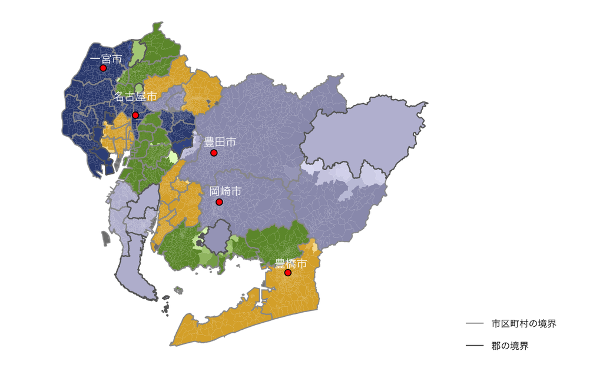

# アルゴリズム設定

- 各選挙区の人口 : (県内の総人口 / 選挙区数) ±15%
- アルゴリズムが導出する案の総数 : 25,000
- 有効な区割り案（飛び地を生じさせない）の数 : 25,000
- 有効な案から一票の格差が最小の区割り案を選定